# Stratified Summary Tables of Multiple Myeloma Dataset

Xujun Gu

08-01-2025

# Section 1. Stratified Analysis

Note:

Q: What is LDH Pretreatment Level? A: LDH (Lactate Dehydrogenase) is a biomarker often used to assess tumor burden and aggressiveness in multiple myeloma (MM).

Q: What is “5 Schema Discriminator 1: Plasma Cell Myeloma Terminology coded to 1 or 9”. A: This is a SEER variable used to clarify or “discriminate” between overlapping cancer schemas when a site/histology could fit multiple schemas. It can help for staging, coding, or analyzing a specific cancer. If it’s mostly in the bone marrow, it’s multiple myeloma (coded as 1). If plasma cells spill over into the blood, it’s plasma cell leukemia (coded as 9). May need clinician for further explanation.

https://staging.seer.cancer.gov/eod_public/input/1.0/plasma_cell_myeloma/discriminator_1/?version=/eod_public/home/1.2/

## Overall Summary

**Table 1. Overall Groups**

| **Variable** | **N = 346**<sup>1</sup> |
| --- | --- |
| Age at Diagnosis (Years) | 60 (SD=10) (27, 90) |
| Sex |  |
| Female | 152.00 /346 (43.93%) |
| Male | 194.00 /346 (56.07%) |
| Race 1 |  |
| Black | 168.00 /346 (48.55%) |
| White | 178.00 /346 (51.45%) |
| Marital Status 1 |  |
| Married | 198.00 /344 (57.56%) |
| Non-Married | 146.00 /344 (42.44%) |
| (Missing) | 2 |
| Marital Status 2 |  |
| Married | 198.00 /344 (57.56%) |
| Separated or Divorced | 35.00 /344 (10.17%) |
| Single | 89.00 /344 (25.87%) |
| Widowed | 22.00 /344 (6.40%) |
| (Missing) | 2 |
| Lymph_Node_Dissected_Flag |  |
| No | 346.00 /346 (100.00%) |
| Diagnostic_Flag |  |
| No | 21.00 /346 (6.07%) |
| Yes | 325.00 /346 (93.93%) |
| Surgery1_Flag |  |
| No | 342.00 /346 (98.84%) |
| Yes | 4.00 /346 (1.16%) |
| Surgery2_Flag |  |
| No | 342.00 /346 (98.84%) |
| Yes | 4.00 /346 (1.16%) |
| Chemo_Flag |  |
| No | 37.00 /346 (10.69%) |

[output cut: 52 more lines]

<sup>1</sup> Mean (SD=SD) (Min, Max); n /N (%)

## High Risk Cytogenetics

**Table 2.1. High Risk Cytogenetics**

| **Variable** | **Overall** N = 196<sup>1</sup> | **High Risk** N = 75<sup>1</sup> | **Not High Risk** N = 121<sup>1</sup> |
| --- | --- | --- | --- |
| Age at Diagnosis (Years) | 60 (9) | 59 (10) | 60 (9) |
| Sex |  |  |  |
| Female | 90 (45.92%) | 32 (42.67%) | 58 (47.93%) |
| Male | 106 (54.08%) | 43 (57.33%) | 63 (52.07%) |
| Race 1 |  |  |  |
| Black | 88 (44.90%) | 32 (42.67%) | 56 (46.28%) |
| White | 108 (55.10%) | 43 (57.33%) | 65 (53.72%) |
| Marital Status 1 |  |  |  |
| Married | 114 (58.16%) | 42 (56.00%) | 72 (59.50%) |
| Non-Married | 82 (41.84%) | 33 (44.00%) | 49 (40.50%) |
| Marital Status 2 |  |  |  |
| Married | 114 (58.16%) | 42 (56.00%) | 72 (59.50%) |
| Separated or Divorced | 24 (12.24%) | 7 (9.33%) | 17 (14.05%) |
| Single | 48 (24.49%) | 21 (28.00%) | 27 (22.31%) |
| Widowed | 10 (5.10%) | 5 (6.67%) | 5 (4.13%) |
| Lymph_Node_Dissected_Flag |  |  |  |
| No | 196 (100.00%) | 75 (100.00%) | 121 (100.00%) |
| Diagnostic_Flag |  |  |  |
| No | 10 (5.10%) | 5 (6.67%) | 5 (4.13%) |
| Yes | 186 (94.90%) | 70 (93.33%) | 116 (95.87%) |
| Surgery1_Flag |  |  |  |
| No | 194 (98.98%) | 75 (100.00%) | 119 (98.35%) |
| Yes | 2 (1.02%) | 0 (0.00%) | 2 (1.65%) |
| Surgery2_Flag |  |  |  |
| No | 194 (98.98%) | 75 (100.00%) | 119 (98.35%) |
| Yes | 2 (1.02%) | 0 (0.00%) | 2 (1.65%) |
| Chemo_Flag |  |  |  |
| No | 10 (5.10%) | 2 (2.67%) | 8 (6.61%) |
| Yes | 186 (94.90%) | 73 (97.33%) | 113 (93.39%) |
| Radiation_Flag |  |  |  |
| No | 156 (79.59%) | 61 (81.33%) | 95 (78.51%) |
| Yes | 40 (20.41%) | 14 (18.67%) | 26 (21.49%) |
| Hormone_Flag |  |  |  |
| No | 14 (7.14%) | 4 (5.33%) | 10 (8.26%) |
| Yes | 182 (92.86%) | 71 (94.67%) | 111 (91.74%) |
| Immuno_Flag |  |  |  |
| No | 23 (11.73%) | 8 (10.67%) | 15 (12.40%) |
| Yes | 173 (88.27%) | 67 (89.33%) | 106 (87.60%) |
| Other_Treatment_Flag |  |  |  |
| No | 191 (97.45%) | 71 (94.67%) | 120 (99.17%) |
| Yes | 5 (2.55%) | 4 (5.33%) | 1 (0.83%) |
| Transplant_Flag |  |  |  |
| No | 41 (20.92%) | 15 (20.00%) | 26 (21.49%) |
| Yes | 155 (79.08%) | 60 (80.00%) | 95 (78.51%) |
| Insurance Type |  |  |  |
| Private | 112 (58.64%) | 45 (61.64%) | 67 (56.78%) |
| Public | 79 (41.36%) | 28 (38.36%) | 51 (43.22%) |
| (Missing) | 5 | 2 | 3 |
| Primary Payer at Diagnosis |  |  |  |
| Medicaid | 16 (8.38%) | 4 (5.48%) | 12 (10.17%) |
| Medicare | 60 (31.41%) | 22 (30.14%) | 38 (32.20%) |
| Military | 3 (1.57%) | 2 (2.74%) | 1 (0.85%) |
| Private | 112 (58.64%) | 45 (61.64%) | 67 (56.78%) |
| (Missing) | 5 | 2 | 3 |
| RISS |  |  |  |
| I | 27 (25.00%) | 0 (0.00%) | 27 (39.13%) |
| II | 62 (57.41%) | 25 (64.10%) | 37 (53.62%) |
| III | 19 (17.59%) | 14 (35.90%) | 5 (7.25%) |
| (Missing) | 88 | 36 | 52 |
| ISS |  |  |  |
| I | 45 (34.88%) | 12 (25.53%) | 33 (40.24%) |
| II | 50 (38.76%) | 21 (44.68%) | 29 (35.37%) |
| III | 34 (26.36%) | 14 (29.79%) | 20 (24.39%) |
| (Missing) | 67 | 28 | 39 |

<sup>1</sup> Mean (SD); n (%)

## LDH Pretreatment Level

**Table 2.2. LDH Pretreatment Level**

| **Variable** | **Overall** N = 223<sup>1</sup> | **High LDH** N = 49<sup>1</sup> | **Normal LDH** N = 174<sup>1</sup> |
| --- | --- | --- | --- |
| Age at Diagnosis (Years) | 61 (11) | 61 (12) | 61 (11) |
| Sex |  |  |  |
| Female | 102 (45.74%) | 21 (42.86%) | 81 (46.55%) |
| Male | 121 (54.26%) | 28 (57.14%) | 93 (53.45%) |
| Race 1 |  |  |  |
| Black | 111 (49.78%) | 24 (48.98%) | 87 (50.00%) |
| White | 112 (50.22%) | 25 (51.02%) | 87 (50.00%) |
| Marital Status 1 |  |  |  |
| Married | 128 (57.66%) | 27 (55.10%) | 101 (58.38%) |
| Non-Married | 94 (42.34%) | 22 (44.90%) | 72 (41.62%) |
| (Missing) | 1 | 0 | 1 |
| Marital Status 2 |  |  |  |
| Married | 128 (57.66%) | 27 (55.10%) | 101 (58.38%) |
| Separated or Divorced | 22 (9.91%) | 5 (10.20%) | 17 (9.83%) |
| Single | 59 (26.58%) | 14 (28.57%) | 45 (26.01%) |
| Widowed | 13 (5.86%) | 3 (6.12%) | 10 (5.78%) |
| (Missing) | 1 | 0 | 1 |
| Lymph_Node_Dissected_Flag |  |  |  |
| No | 223 (100.00%) | 49 (100.00%) | 174 (100.00%) |
| Diagnostic_Flag |  |  |  |
| No | 10 (4.48%) | 3 (6.12%) | 7 (4.02%) |
| Yes | 213 (95.52%) | 46 (93.88%) | 167 (95.98%) |
| Surgery1_Flag |  |  |  |
| No | 220 (98.65%) | 47 (95.92%) | 173 (99.43%) |
| Yes | 3 (1.35%) | 2 (4.08%) | 1 (0.57%) |
| Surgery2_Flag |  |  |  |
| No | 220 (98.65%) | 47 (95.92%) | 173 (99.43%) |
| Yes | 3 (1.35%) | 2 (4.08%) | 1 (0.57%) |
| Chemo_Flag |  |  |  |
| No | 31 (13.90%) | 6 (12.24%) | 25 (14.37%) |
| Yes | 192 (86.10%) | 43 (87.76%) | 149 (85.63%) |
| Radiation_Flag |  |  |  |
| No | 178 (79.82%) | 38 (77.55%) | 140 (80.46%) |
| Yes | 45 (20.18%) | 11 (22.45%) | 34 (19.54%) |
| Hormone_Flag |  |  |  |
| No | 32 (14.35%) | 6 (12.24%) | 26 (14.94%) |
| Yes | 191 (85.65%) | 43 (87.76%) | 148 (85.06%) |
| Immuno_Flag |  |  |  |
| No | 51 (22.87%) | 15 (30.61%) | 36 (20.69%) |
| Yes | 172 (77.13%) | 34 (69.39%) | 138 (79.31%) |
| Other_Treatment_Flag |  |  |  |
| No | 216 (96.86%) | 48 (97.96%) | 168 (96.55%) |
| Yes | 7 (3.14%) | 1 (2.04%) | 6 (3.45%) |
| Transplant_Flag |  |  |  |
| No | 92 (41.26%) | 27 (55.10%) | 65 (37.36%) |
| Yes | 131 (58.74%) | 22 (44.90%) | 109 (62.64%) |
| Insurance Type |  |  |  |
| Private | 116 (52.25%) | 28 (57.14%) | 88 (50.87%) |
| Public | 106 (47.75%) | 21 (42.86%) | 85 (49.13%) |
| (Missing) | 1 | 0 | 1 |
| Primary Payer at Diagnosis |  |  |  |
| Medicaid | 21 (9.46%) | 5 (10.20%) | 16 (9.25%) |
| Medicare | 82 (36.94%) | 16 (32.65%) | 66 (38.15%) |
| Military | 3 (1.35%) | 0 (0.00%) | 3 (1.73%) |
| Private | 116 (52.25%) | 28 (57.14%) | 88 (50.87%) |
| (Missing) | 1 | 0 | 1 |
| RISS |  |  |  |
| I | 27 (22.69%) | 0 (0.00%) | 27 (30.00%) |
| II | 62 (52.10%) | 9 (31.03%) | 53 (58.89%) |
| III | 30 (25.21%) | 20 (68.97%) | 10 (11.11%) |
| (Missing) | 104 | 20 | 84 |
| ISS |  |  |  |
| I | 75 (37.88%) | 12 (27.91%) | 63 (40.65%) |
| II | 65 (32.83%) | 11 (25.58%) | 54 (34.84%) |
| III | 58 (29.29%) | 20 (46.51%) | 38 (24.52%) |
| (Missing) | 25 | 6 | 19 |

<sup>1</sup> Mean (SD); n (%)

## Serum Beta-2 Microglobulin Level

**Table 2.3. Serum Beta-2 Microglobulin Pretreatment Level**

| **Variable** | **Overall** N = 246<sup>1</sup> | **< 3.5 mg/L** N = 122<sup>1</sup> | **>= 3.5 mg/L < 5.5 mg/L** N = 57<sup>1</sup> | **>= 5.5 mg/L** N = 67<sup>1</sup> |
| --- | --- | --- | --- | --- |
| Age at Diagnosis (Years) | 60 (11) | 61 (10) | 60 (12) | 60 (12) |
| Sex |  |  |  |  |
| Female | 106 (43.09%) | 57 (46.72%) | 22 (38.60%) | 27 (40.30%) |
| Male | 140 (56.91%) | 65 (53.28%) | 35 (61.40%) | 40 (59.70%) |
| Race 1 |  |  |  |  |
| Black | 122 (49.59%) | 64 (52.46%) | 26 (45.61%) | 32 (47.76%) |
| White | 124 (50.41%) | 58 (47.54%) | 31 (54.39%) | 35 (52.24%) |
| Marital Status 1 |  |  |  |  |
| Married | 143 (58.37%) | 66 (54.10%) | 36 (64.29%) | 41 (61.19%) |
| Non-Married | 102 (41.63%) | 56 (45.90%) | 20 (35.71%) | 26 (38.81%) |
| (Missing) | 1 | 0 | 1 | 0 |
| Marital Status 2 |  |  |  |  |
| Married | 143 (58.37%) | 66 (54.10%) | 36 (64.29%) | 41 (61.19%) |
| Separated or Divorced | 22 (8.98%) | 17 (13.93%) | 3 (5.36%) | 2 (2.99%) |
| Single | 63 (25.71%) | 30 (24.59%) | 13 (23.21%) | 20 (29.85%) |
| Widowed | 17 (6.94%) | 9 (7.38%) | 4 (7.14%) | 4 (5.97%) |
| (Missing) | 1 | 0 | 1 | 0 |
| Lymph_Node_Dissected_Flag |  |  |  |  |
| No | 246 (100.00%) | 122 (100.00%) | 57 (100.00%) | 67 (100.00%) |
| Diagnostic_Flag |  |  |  |  |
| No | 12 (4.88%) | 5 (4.10%) | 4 (7.02%) | 3 (4.48%) |
| Yes | 234 (95.12%) | 117 (95.90%) | 53 (92.98%) | 64 (95.52%) |
| Surgery1_Flag |  |  |  |  |
| No | 243 (98.78%) | 120 (98.36%) | 57 (100.00%) | 66 (98.51%) |
| Yes | 3 (1.22%) | 2 (1.64%) | 0 (0.00%) | 1 (1.49%) |
| Surgery2_Flag |  |  |  |  |
| No | 243 (98.78%) | 120 (98.36%) | 57 (100.00%) | 66 (98.51%) |
| Yes | 3 (1.22%) | 2 (1.64%) | 0 (0.00%) | 1 (1.49%) |
| Chemo_Flag |  |  |  |  |
| No | 31 (12.60%) | 15 (12.30%) | 7 (12.28%) | 9 (13.43%) |
| Yes | 215 (87.40%) | 107 (87.70%) | 50 (87.72%) | 58 (86.57%) |
| Radiation_Flag |  |  |  |  |
| No | 196 (79.67%) | 90 (73.77%) | 48 (84.21%) | 58 (86.57%) |
| Yes | 50 (20.33%) | 32 (26.23%) | 9 (15.79%) | 9 (13.43%) |
| Hormone_Flag |  |  |  |  |
| No | 33 (13.41%) | 14 (11.48%) | 9 (15.79%) | 10 (14.93%) |
| Yes | 213 (86.59%) | 108 (88.52%) | 48 (84.21%) | 57 (85.07%) |
| Immuno_Flag |  |  |  |  |
| No | 55 (22.36%) | 23 (18.85%) | 11 (19.30%) | 21 (31.34%) |
| Yes | 191 (77.64%) | 99 (81.15%) | 46 (80.70%) | 46 (68.66%) |
| Other_Treatment_Flag |  |  |  |  |
| No | 240 (97.56%) | 120 (98.36%) | 57 (100.00%) | 63 (94.03%) |
| Yes | 6 (2.44%) | 2 (1.64%) | 0 (0.00%) | 4 (5.97%) |
| Transplant_Flag |  |  |  |  |
| No | 91 (36.99%) | 37 (30.33%) | 17 (29.82%) | 37 (55.22%) |
| Yes | 155 (63.01%) | 85 (69.67%) | 40 (70.18%) | 30 (44.78%) |
| Insurance Type |  |  |  |  |
| Private | 134 (55.14%) | 62 (51.24%) | 34 (60.71%) | 38 (57.58%) |
| Public | 109 (44.86%) | 59 (48.76%) | 22 (39.29%) | 28 (42.42%) |
| (Missing) | 3 | 1 | 1 | 1 |
| Primary Payer at Diagnosis |  |  |  |  |
| Medicaid | 22 (9.05%) | 12 (9.92%) | 4 (7.14%) | 6 (9.09%) |
| Medicare | 83 (34.16%) | 46 (38.02%) | 18 (32.14%) | 19 (28.79%) |
| Military | 4 (1.65%) | 1 (0.83%) | 0 (0.00%) | 3 (4.55%) |
| Private | 134 (55.14%) | 62 (51.24%) | 34 (60.71%) | 38 (57.58%) |
| (Missing) | 3 | 1 | 1 | 1 |
| RISS |  |  |  |  |
| I | 27 (22.69%) | 27 (52.94%) | 0 (0.00%) | 0 (0.00%) |
| II | 62 (52.10%) | 24 (47.06%) | 27 (100.00%) | 11 (26.83%) |
| III | 30 (25.21%) | 0 (0.00%) | 0 (0.00%) | 30 (73.17%) |
| (Missing) | 127 | 71 | 30 | 26 |
| ISS |  |  |  |  |
| I | 87 (37.18%) | 87 (76.32%) | 0 (0.00%) | 0 (0.00%) |
| II | 80 (34.19%) | 27 (23.68%) | 53 (100.00%) | 0 (0.00%) |
| III | 67 (28.63%) | 0 (0.00%) | 0 (0.00%) | 67 (100.00%) |
| (Missing) | 12 | 8 | 4 | 0 |

<sup>1</sup> Mean (SD); n (%)

## SCT

**Table 2.4 Ruoyi_table_check_SCT**

| **Variable** | **Overall** N = 346<sup>1</sup> | **No** N = 106<sup>1</sup> | **Yes** N = 240<sup>1</sup> | **p-value**<sup>2</sup> |
| --- | --- | --- | --- | --- |
| Age at Diagnosis (Years) | 60 (10) | 64 (13) | 58 (9) | <0.001 |
| age_cat |  |  |  | <0.001 |
| Age 65 to 74 | 99 (28.61%) | 33 (31.13%) | 66 (27.50%) |  |
| Age Over 75 | 25 (7.23%) | 24 (22.64%) | 1 (0.42%) |  |
| Age Under 65 | 222 (64.16%) | 49 (46.23%) | 173 (72.08%) |  |
| Sex |  |  |  | 0.5 |
| Female | 152 (43.93%) | 44 (41.51%) | 108 (45.00%) |  |
| Male | 194 (56.07%) | 62 (58.49%) | 132 (55.00%) |  |
| Race 1 |  |  |  | 0.003 |
| Black | 168 (48.55%) | 64 (60.38%) | 104 (43.33%) |  |
| White | 178 (51.45%) | 42 (39.62%) | 136 (56.67%) |  |
| Marital Status 1 |  |  |  | <0.001 |
| Married | 198 (57.56%) | 45 (42.86%) | 153 (64.02%) |  |
| Non-Married | 146 (42.44%) | 60 (57.14%) | 86 (35.98%) |  |
| (Missing) | 2 | 1 | 1 |  |
| Marital Status 2 |  |  |  | 0.002 |
| Married | 198 (57.56%) | 45 (42.86%) | 153 (64.02%) |  |
| Separated or Divorced | 35 (10.17%) | 12 (11.43%) | 23 (9.62%) |  |
| Single | 89 (25.87%) | 37 (35.24%) | 52 (21.76%) |  |
| Widowed | 22 (6.40%) | 11 (10.48%) | 11 (4.60%) |  |
| (Missing) | 2 | 1 | 1 |  |
| Insurance Type |  |  |  | <0.001 |
| Private | 188 (55.29%) | 31 (29.52%) | 157 (66.81%) |  |
| Public | 152 (44.71%) | 74 (70.48%) | 78 (33.19%) |  |
| (Missing) | 6 | 1 | 5 |  |
| Primary Payer at Diagnosis |  |  |  | <0.001 |
| Medicaid | 26 (7.65%) | 14 (13.33%) | 12 (5.11%) |  |
| Medicare | 117 (34.41%) | 57 (54.29%) | 60 (25.53%) |  |
| Military | 9 (2.65%) | 3 (2.86%) | 6 (2.55%) |  |
| Private | 188 (55.29%) | 31 (29.52%) | 157 (66.81%) |  |
| (Missing) | 6 | 1 | 5 |  |
| High Risk Cytogenetics |  |  |  | 0.8 |
| High Risk | 75 (38.27%) | 15 (36.59%) | 60 (38.71%) |  |
| Not High Risk | 121 (61.73%) | 26 (63.41%) | 95 (61.29%) |  |
| (Missing) | 150 | 65 | 85 |  |
| LDH (Lactate Dehydrogenase) Pretreatment Level |  |  |  | 0.026 |
| High LDH | 49 (21.97%) | 27 (29.35%) | 22 (16.79%) |  |
| Normal LDH | 174 (78.03%) | 65 (70.65%) | 109 (83.21%) |  |
| (Missing) | 123 | 14 | 109 |  |
| Serum Beta-2 Microglobulin Pretreatment Level |  |  |  | 0.001 |
| < 3.5 mg/L | 122 (49.59%) | 37 (40.66%) | 85 (54.84%) |  |
| >= 3.5 mg/L < 5.5 mg/L | 57 (23.17%) | 17 (18.68%) | 40 (25.81%) |  |
| >= 5.5 mg/L | 67 (27.24%) | 37 (40.66%) | 30 (19.35%) |  |
| (Missing) | 100 | 15 | 85 |  |
| RISS |  |  |  | 0.008 |
| I | 27 (22.69%) | 4 (10.00%) | 23 (29.11%) |  |
| II | 62 (52.10%) | 20 (50.00%) | 42 (53.16%) |  |
| III | 30 (25.21%) | 16 (40.00%) | 14 (17.72%) |  |
| (Missing) | 227 | 66 | 161 |  |
| ISS |  |  |  | 0.002 |
| I | 87 (37.18%) | 26 (29.55%) | 61 (41.78%) |  |
| II | 80 (34.19%) | 25 (28.41%) | 55 (37.67%) |  |
| III | 67 (28.63%) | 37 (42.05%) | 30 (20.55%) |  |
| (Missing) | 112 | 18 | 94 |  |

<sup>1</sup> Mean (SD); n (%)  
<sup>2</sup> Wilcoxon rank sum test; Pearson’s Chi-squared test; Fisher’s exact test

## Race

**Table 2.5 Race Stratified Table**

| **Variable** | **Overall** N = 346<sup>1</sup> | **Black** N = 168<sup>1</sup> | **White** N = 178<sup>1</sup> | **p-value**<sup>2</sup> |
| --- | --- | --- | --- | --- |
| Age at Diagnosis (Years) | 60 (10) | 58 (11) | 62 (9) | 0.004 |
| age_cat |  |  |  | 0.090 |
| Age 65 to 74 | 99 (28.61%) | 39 (23.21%) | 60 (33.71%) |  |
| Age Over 75 | 25 (7.23%) | 14 (8.33%) | 11 (6.18%) |  |
| Age Under 65 | 222 (64.16%) | 115 (68.45%) | 107 (60.11%) |  |
| Sex |  |  |  | <0.001 |
| Female | 152 (43.93%) | 97 (57.74%) | 55 (30.90%) |  |
| Male | 194 (56.07%) | 71 (42.26%) | 123 (69.10%) |  |
| Marital Status 1 |  |  |  | <0.001 |
| Married | 198 (57.56%) | 69 (41.07%) | 129 (73.30%) |  |
| Non-Married | 146 (42.44%) | 99 (58.93%) | 47 (26.70%) |  |
| (Missing) | 2 | 0 | 2 |  |
| Marital Status 2 |  |  |  | <0.001 |
| Married | 198 (57.56%) | 69 (41.07%) | 129 (73.30%) |  |
| Separated or Divorced | 35 (10.17%) | 21 (12.50%) | 14 (7.95%) |  |
| Single | 89 (25.87%) | 65 (38.69%) | 24 (13.64%) |  |
| Widowed | 22 (6.40%) | 13 (7.74%) | 9 (5.11%) |  |
| (Missing) | 2 | 0 | 2 |  |
| Insurance Type |  |  |  | 0.024 |
| Private | 188 (55.29%) | 82 (49.10%) | 106 (61.27%) |  |
| Public | 152 (44.71%) | 85 (50.90%) | 67 (38.73%) |  |
| (Missing) | 6 | 1 | 5 |  |
| Primary Payer at Diagnosis |  |  |  | <0.001 |
| Medicaid | 26 (7.65%) | 23 (13.77%) | 3 (1.73%) |  |
| Medicare | 117 (34.41%) | 56 (33.53%) | 61 (35.26%) |  |
| Military | 9 (2.65%) | 6 (3.59%) | 3 (1.73%) |  |
| Private | 188 (55.29%) | 82 (49.10%) | 106 (61.27%) |  |
| (Missing) | 6 | 1 | 5 |  |
| High Risk Cytogenetics |  |  |  | 0.6 |
| High Risk | 75 (38.27%) | 32 (36.36%) | 43 (39.81%) |  |

[output cut: 53 more lines]

<sup>1</sup> Mean (SD); n (%)  
<sup>2</sup> Wilcoxon rank sum test; Pearson’s Chi-squared test; Fisher’s exact test

# Logistic Regression

Running logistic regression for all different treatement to see the difference

## SCT

| **Characteristic** | **log(OR)** | **95% CI** | **p-value** |
| --- | --- | --- | --- |
| Sex_bin | -0.57 | -1.3, 0.11 | 0.10 |
| Race 1 |  |  |  |
| White | — | — |  |
| Black | -0.59 | -1.3, 0.11 | 0.10 |
| Insurance Type |  |  |  |
| Private | — | — |  |
| Public | -1.7 | -2.3, -1.0 | <0.001 |
| Marital Status 1 |  |  |  |
| Married | — | — |  |
| Non-Married | -1.0 | -1.7, -0.29 | 0.006 |
| Spanish Origin |  |  |  |
| Hispanic | — | — |  |
| Non-Hispanic | -1.0 | -4.1, 1.0 | 0.4 |
| Family Cancer History |  |  |  |
| 0 - No | — | — |  |
| 1 - Yes | -0.13 | -0.83, 0.56 | 0.7 |
| 9 - Unknown | 0.08 | -1.2, 1.4 | 0.9 |
| Serum Beta-2 Microglobulin Pretreatment Level |  |  |  |
| < 3.5 mg/L | — | — |  |
| >= 3.5 mg/L < 5.5 mg/L | -0.16 | -0.99, 0.70 | 0.7 |
| >= 5.5 mg/L | -1.3 | -2.1, -0.54 | 0.001 |

Abbreviations: CI = Confidence Interval, OR = Odds Ratio

## Chemo

| **Characteristic** | **log(OR)** | **95% CI** | **p-value** |
| --- | --- | --- | --- |
| Sex_bin | -0.14 | -1.0, 0.73 | 0.8 |
| Race 1 |  |  |  |
| White | — | — |  |
| Black | 0.39 | -0.51, 1.3 | 0.4 |
| Insurance Type |  |  |  |
| Private | — | — |  |
| Public | -1.2 | -2.1, -0.33 | 0.008 |
| Marital Status 1 |  |  |  |
| Married | — | — |  |
| Non-Married | -0.34 | -1.3, 0.59 | 0.5 |
| Spanish Origin |  |  |  |
| Hispanic | — | — |  |
| Non-Hispanic | -15 |  | >0.9 |
| Family Cancer History |  |  |  |
| 0 - No | — | — |  |
| 1 - Yes | 0.07 | -0.82, 0.93 | 0.9 |
| 9 - Unknown | 1.1 | -0.70, 4.0 | 0.3 |
| Serum Beta-2 Microglobulin Pretreatment Level |  |  |  |
| < 3.5 mg/L | — | — |  |
| >= 3.5 mg/L < 5.5 mg/L | -0.18 | -1.2, 0.94 | 0.7 |
| >= 5.5 mg/L | -0.07 | -1.0, 0.98 | 0.9 |

Abbreviations: CI = Confidence Interval, OR = Odds Ratio

## Immuno

| **Characteristic** | **log(OR)** | **95% CI** | **p-value** |
| --- | --- | --- | --- |
| Sex_bin | -0.44 | -1.2, 0.28 | 0.2 |
| Race 1 |  |  |  |
| White | — | — |  |
| Black | -0.09 | -0.85, 0.66 | 0.8 |
| Insurance Type |  |  |  |
| Private | — | — |  |
| Public | -1.1 | -1.8, -0.37 | 0.003 |
| Marital Status 1 |  |  |  |
| Married | — | — |  |
| Non-Married | -0.75 | -1.5, 0.00 | 0.052 |
| Spanish Origin |  |  |  |
| Hispanic | — | — |  |
| Non-Hispanic | 0.58 | -1.5, 2.4 | 0.5 |
| Family Cancer History |  |  |  |
| 0 - No | — | — |  |
| 1 - Yes | 0.11 | -0.62, 0.83 | 0.8 |
| 9 - Unknown | 0.47 | -0.86, 2.1 | 0.5 |
| Serum Beta-2 Microglobulin Pretreatment Level |  |  |  |
| < 3.5 mg/L | — | — |  |
| >= 3.5 mg/L < 5.5 mg/L | -0.06 | -0.95, 0.89 | 0.9 |
| >= 5.5 mg/L | -0.69 | -1.5, 0.09 | 0.083 |

Abbreviations: CI = Confidence Interval, OR = Odds Ratio

## Hormone

| **Characteristic** | **log(OR)** | **95% CI** | **p-value** |
| --- | --- | --- | --- |
| Sex_bin | -0.09 | -1.0, 0.80 | 0.8 |
| Race 1 |  |  |  |
| White | — | — |  |
| Black | 0.50 | -0.47, 1.5 | 0.3 |
| Insurance Type |  |  |  |
| Private | — | — |  |
| Public | -1.5 | -2.5, -0.59 | 0.002 |
| Marital Status 1 |  |  |  |
| Married | — | — |  |
| Non-Married | -0.50 | -1.5, 0.47 | 0.3 |
| Spanish Origin |  |  |  |
| Hispanic | — | — |  |
| Non-Hispanic | -15 |  | >0.9 |
| Family Cancer History |  |  |  |
| 0 - No | — | — |  |
| 1 - Yes | 0.02 | -0.89, 0.90 | >0.9 |
| 9 - Unknown | 1.2 | -0.67, 4.2 | 0.3 |
| LDH (Lactate Dehydrogenase) Pretreatment Level |  |  |  |
| High LDH | — | — |  |
| Normal LDH | -0.62 | -1.8, 0.40 | 0.3 |
| Serum Beta-2 Microglobulin Pretreatment Level |  |  |  |
| < 3.5 mg/L | — | — |  |
| >= 3.5 mg/L < 5.5 mg/L | -0.45 | -1.5, 0.72 | 0.4 |
| >= 5.5 mg/L | -0.61 | -1.6, 0.40 | 0.2 |

Abbreviations: CI = Confidence Interval, OR = Odds Ratio

# Treatment Data list

1. Radiation Therapy Reason for No Radiation Summary of Therapy gives the information on whether patients received the Radiation Therapy or not. Comments – Radiation Treatment Date Radiation Started Date Radiation Ended
2. Chemotherapy Date of First Chemotherapy Chemotherapy Comments – Chemotherapy Treatment
3. Surgery Date of Surgical Diagnostic and Staging Procedure (Diagnostic) Date of Surgery
4. Hormone (Corticosteroid) Therapy Date of First Hormone Therapy Comments – Hormone Treatment
5. Immunotherapy / Biologic Therapy Date of First Immunotherapy Immunotherapy Comments – Immunotherapy Treatment
6. Hematologic Transplant / Endocrine Procedure Date of Hematologic Transplant/Endocrine Procedure
7. “Other” Therapy Date Other Treatment Started Other Treatment Comments – Other Treatment

#Data Visualization (example)

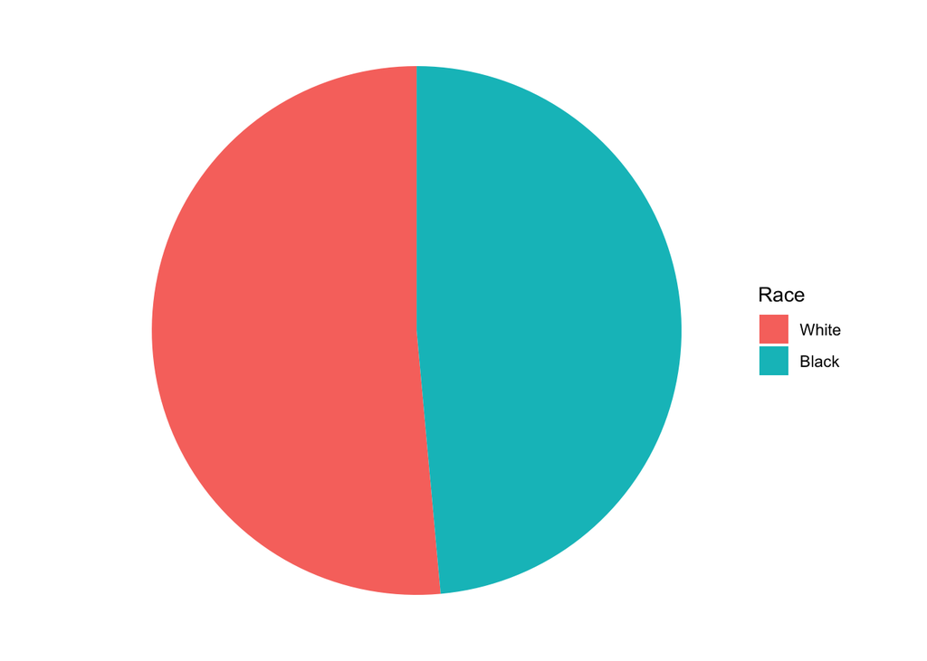

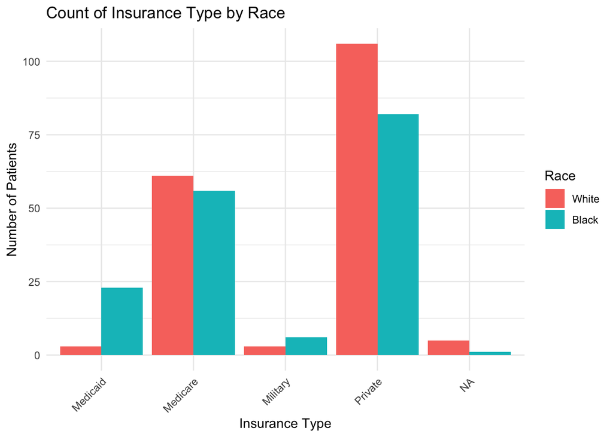